# Introdução

Este relatório objetiva apresentar e discutir os resultados obtidos em duas sessões de experimentos realizados no Instituto de Física da Universidade Federal da Bahia, nos dias 18 e 20 de abril de 2018.

Os dados obtidos foram organizados e tratados utilizando o ambiente de programação “R”. Todas as medidas presentes nos códigos R são dadas no SI (Sistema Internacional de Medidas), a menos que explicitado o contrário. Todas as medidas presentes em gráficos e tabelas estarão acompanhadas da unidade utilizada.

## Parâmetros dos experimentos

```r
# Massa do carrinho com bandeira.
p.massa = 0.2107

# Tamanho da régua
p.regua = 2

# Posição inicial do fim da bandeira em relação a origem da régua.
p.bandeira = 0.204

# Tamanho da bandeira.
p.tam_bandeira = 0.0975

# Distância entre sensores adjacentes
# em cada um dos experimentos de movimento retilíneo.
p.MRU.distancias = c(0.373, 0.322, 0.655, 0.37)
p.MRU.posicoes = cumsum(p.MRU.distancias) - p.bandeira
p.MUV.distancias = c(0.207 + p.bandeira, 0.414, 0.427, 0.49)
p.MUV.posicoes = cumsum(p.MUV.distancias) - p.bandeira
p.MUV_flag.distancias = c(0.406, 0.49, 0.354, 0.495)
p.MUV_flag.posicoes = cumsum(p.MUV.distancias) - p.bandeira

# Altura do plano inclinado em função do deslocamento
# do carrinho em cada um dos experimentos de MUV.
p.MUV.h = function(s = 0) { 0.012 * (p.regua - p.bandeira - s) / p.regua }
p.MUV_flag.h = function(s = 0) {
  0.005 * (p.regua - p.bandeira - s) / p.regua
}

#Massa e diâmetro da bolinha do pêndulo
p.massa_bola = 0.0676
p.diametro_bola = 0.025

#Distância entre o pino do pêndulo e o chão
p.altura_pino = 1.142

#Ângulo em que a bolinha era abandonada
p.angulo_pendulo = deg2rad(5)
```

## Dados dos experimentos

Os dados dos experimentos foram carregados a partir de arquivos `.csv` previamente construídos a partir das anotações feitas durante a aula.

```r
dados.MRU = read.csv("mru.csv")
dados.MUV = read.csv("muv.csv")
dados.MUV_flag = read.csv("muv_flag.csv")
dados.pendulo = read.csv("pendulo.csv")
```

## Funções e constantes

Algumas funções e constantes foram definidas com o intuito de tornar tais trechos de código reutilizáveis.

```r
# Constantes comuns (physics)
ph.G = 9.7833

# Funções comuns (physics)
ph.peso = function(m, g = ph.G) { m*g }
ph.e.potencial = function(m, h, g = ph.G) { m*g*h }
ph.e.cinetica = function(v, m) { 0.5*m*v^2 }
ph.trabalho = function(f, dx, theta) { f*dx*theta }

# Funções MRU
MRU.velocidade = function(ds, dt) { ds/dt }
MRU.deslocamento = function(v, t) { v*t }

# Funções MUV
MUV.velocidade = function(a, t, v0 = 0) { v0 + a*t }
MUV.deslocamento = function(a, t, v0 = 0) { t*v0 + 0.5*a*t^2 }
MUV.aceleracao = function(s, t, v0 = 0) { 2*(s - t*v0)/t^2 }

# Funções Pêndulo
pend.periodo = function(L, g = ph.G){2*pi*sqrt(L/g)}
pend.velocidade_angular = function(L, g = ph.G) { 2*pi/pend.periodo(L, g) }
pend.velocidade = function(L, ang, t = 0, g = ph.G) {
  w = pend.velocidade_angular(L, g)
  return(w * ang * sin(w*t) * L)
}
pend.aceleracao = function(L, ang, t = 0, g = ph.G) {
  w = pend.velocidade_angular(L, g)
  return(-w^2 * ang * cos(w*t) * L)
}
pend.posicao = function(L, ang, t = 0, g = ph.G) {
  L*ang*cos(pend.velocidade_angular(L, g)*t)
}
pend.altura = function(L, ang, t = 0, g = ph.G) {
  w = pend.velocidade_angular(L, g)
  theta = ang*cos(w*t)
  return(L*(1 - cos(theta)))
}
```

# Experimentos

## Movimento Retilíneo

Os experimentos foram realizados num trilho de ar de $2$ metros de comprimento, onde foi colocado um carrinho de $210.7$ gramas com uma bandeira centralizada de $9.75$ centímetros. Tal carrinho foi colocado no ponto mais à esquerda do trilho e foi suspenso por uma fina camada de ar que tornou o atrito no sistema desprezível. Além disso, 4 sensores foram dispostos ao longo desta régua. Em cada experimento estes sensores foram usados de forma diferente, como explicado nas próximas seções.

### Movimento Retilíneo Uniforme

Cada iteração do experimento consistiu no lançamento do carrinho a uma velocidade fixa, com auxílio de uma mola presente no extremo inicial do trilho. No momento do lançamento, 4 *timers* foram disparados: cada um dos timers foi associado a um dos sensores dispostos no trilho. Cada um dos timers parava quando a bandeira do carrinho adentrasse a região de detecção do sensor.

O objetivo do movimento foi analisar o Movimento Retilíneo Uniforme na prática. Para isso, o trilho foi cuidadosamente ajustado de forma com que sua inclinação em relação ao chão fosse desprezível.

As tabelas abaixo mostram as posições onde cada um dos 4 sensores foram colocados ao longo do trilho e, para cada iteração realizada, os tempos registrados por cada um dos sensores.

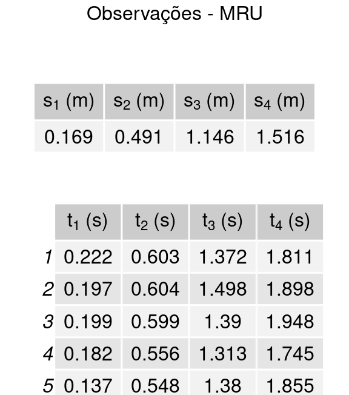

No gráfico abaixo é possível visualizar cada uma das observações obtidas. Além disso, é possível notar que a distribuição das observações lembra uma reta, o que condiz com a natureza do *MRU*. Mais espeficamente, uma reta que descrevesse razoavelmente bem um *MRU* a partir das observações dadas foi gerada a partir do método de regressão linear. Podemos notar que o coeficiente $\beta_1 = 0.805$ obtido indica justamente a taxa de variação do deslocamento com a variação do tempo, ou a **velocidade** do carrinho, que é constante num *MRU* perfeito.

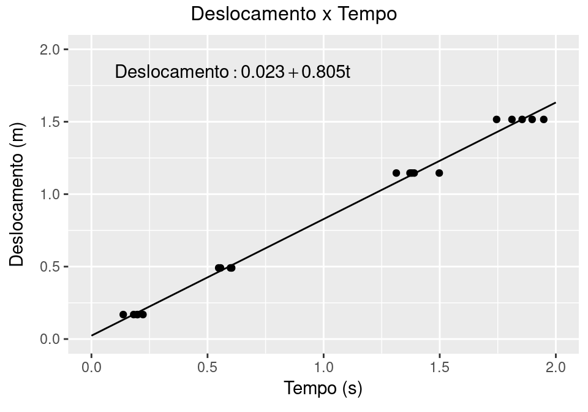

Podemos ainda obter a *velocidade média* ($\Delta s / \Delta t$) no trajeto entre a origem do trilho e cada um dos sensores e obter uma reta através do mesmo método de regressão linear que nos mostre que, de fato, a velocidade do carrinho se mostra praticamente constante durante as iterações do experimento. Note que o coeficiente $\beta_1 = 0.061$ é razoavelmente pequeno, mostrando que há poquíssima variação na *velocidade média* do carrinho durante o trajeto.

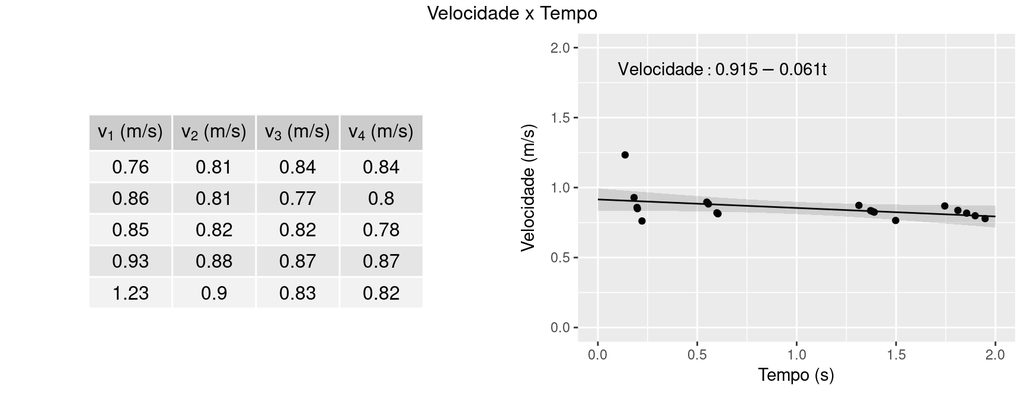

### Movimento Uniformemente Variado

O trilho de ar foi levemente inclinado com ajuda de uma pastilha, fazendo com que o trilho se tornasse um plano inclinado de $2$ metros de comprimento e $1.2$ centímetros de altura (em relação à origem da régua). Na única iteração deste experimento, o carrinho foi solto, a partir do repouso, do começo da régua e os tempos foram medidos de forma semelhante ao *MRU*.

O objetivo do experimento foi analisar o *Movimento Uniformemente Variado* na prática.

As tabelas abaixo mostram as posições onde cada um dos 4 sensores foram colocados ao longo do trilho e os tempos registrados por cada um dos sensores.

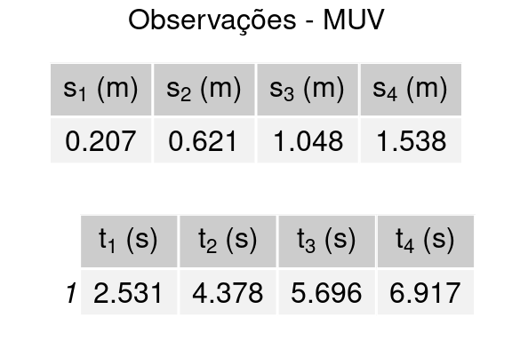

Podemos observar uma função quadrática no deslocamento do carrinho em relação ao tempo, que resultou na função y = 0.032t², indicando maior deslocamento no decorrer do experimento.

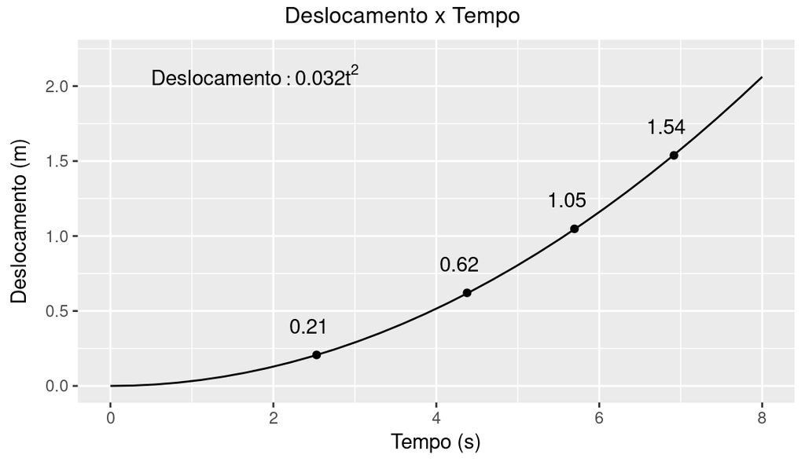

Podemos observar uma função de comportamento linear na função da velocidade do carrinho em relação ao tempo da forma y = 0.064t com um angelo “theta” de 3.69°.

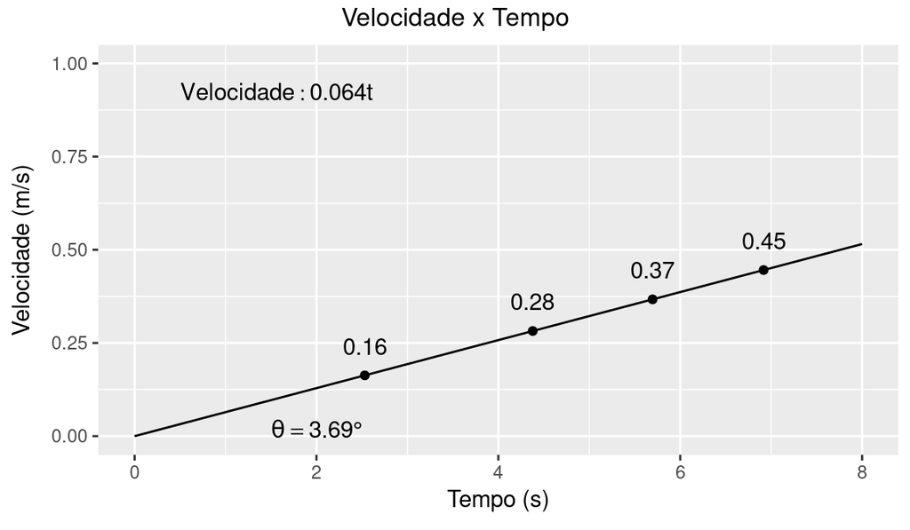

Podemos observar a sobreposição dos gráficos de energia cinética e energia potencial, a função quadrática da energia cinética é representada pela função y = 0.000437t² e a função quadrática da energia potencial é representada por y = 0.022213 - 0.000398t². Os gráficos representam um sistema com maior quantidade de energia potencial que realiza trocas de energia, transformando-a em cinética. Consideramos o sistema como sendo conservativo, ou seja, energia cinética somada com a energia potencial resulta na energia mecânica do sistema.

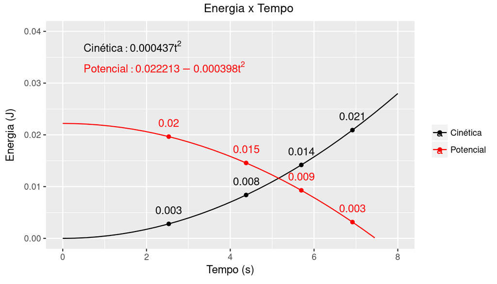

### Movimento Uniformemente Variado (bandeira)

Este gráfico foi plotado segundo o experimento da bandeira, em que setamos os tempos em que a bandeira permanecia dentro de casa sensor e computamos a sua velocidade diante do deslocamento no trilho de ar. Adotamos uma escala de tempo adequada aos resultados do experimento e plotamos a linearidade do comportamento, ajustando pontos sobre a configuração da função.

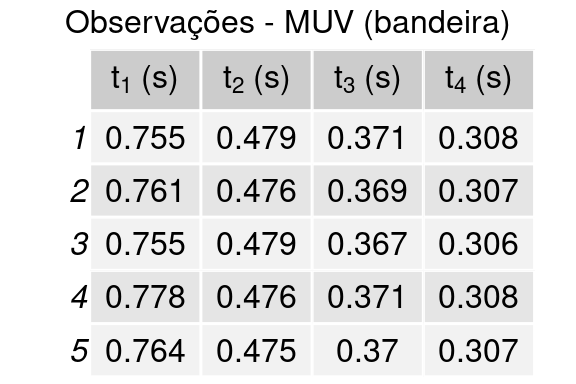

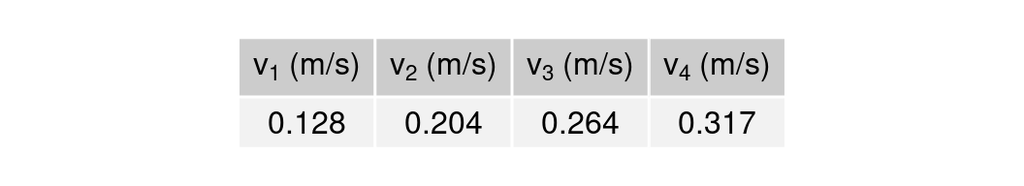

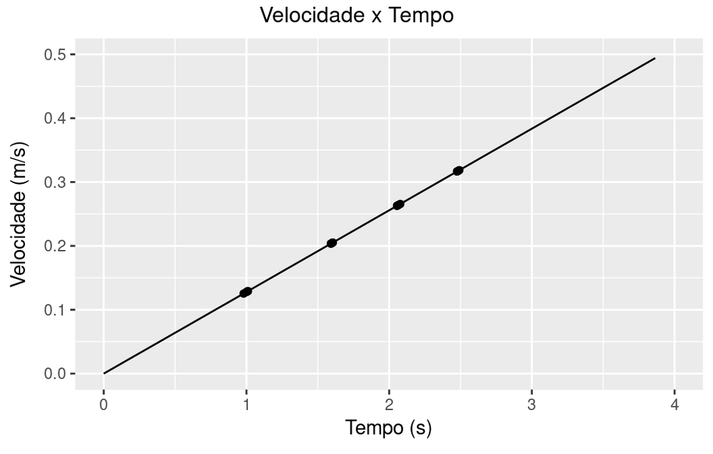

## Pêndulo

O sistema pêndulo consistia num suporte elevado a $1.142$ metros no qual era amarrado um barbante de tamanho variável e em cuja extremidade pendia uma bola de metal de $2.5$ centímetros de diâmetro. Cada medição consistia em abandonar a bolinha, com um ângulo de abertura de 5º, e avaliar quanto tempo demorava para que completasse 5 idas e voltas. O experimento como um todo consistia em variar o tamanho do barbante entre as medições, para analisar como sua extensão está correlacionada com o período do sistema pêndulo.

A tabela abaixo mostra os tempos medidos, para diferentes comprimentos de corda. A última coluna da tabela contém a média das três observações feitas, valor que será usado durante o resto da análise:

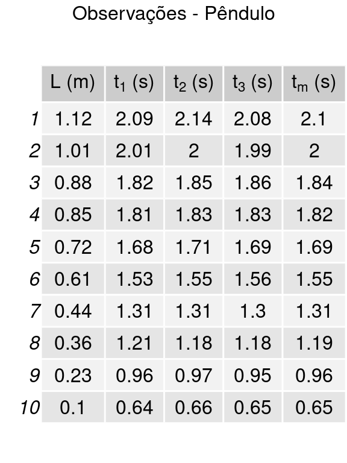

Utilizamos nessa plotagem os tempos registrados na tabela e o comprimento do barbante durante a oscilação. Podemos observar o comportamento de uma função raiz, em que o periodo aumenta de acordo com o comprimento do barbante no pêndulo, este período foi calculado como : T = 2.pi.raiz(L/G).

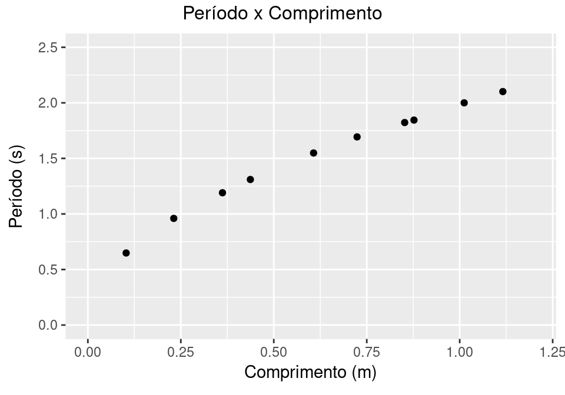

Plotamos juntamente com o gráfico anterior a função do período quadrático que possui comportamento linear em relação ao tempo da forma: y = 0.007 + 3.926L.

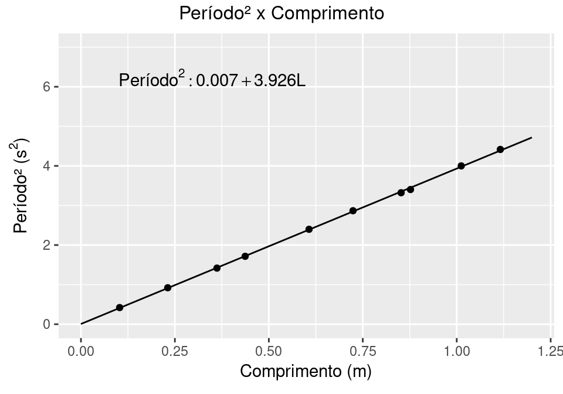

Utilizamos a posição no tempo para plotar a função que possui o comportamento de uma senoide, variando entre -0.10 e 0.10.

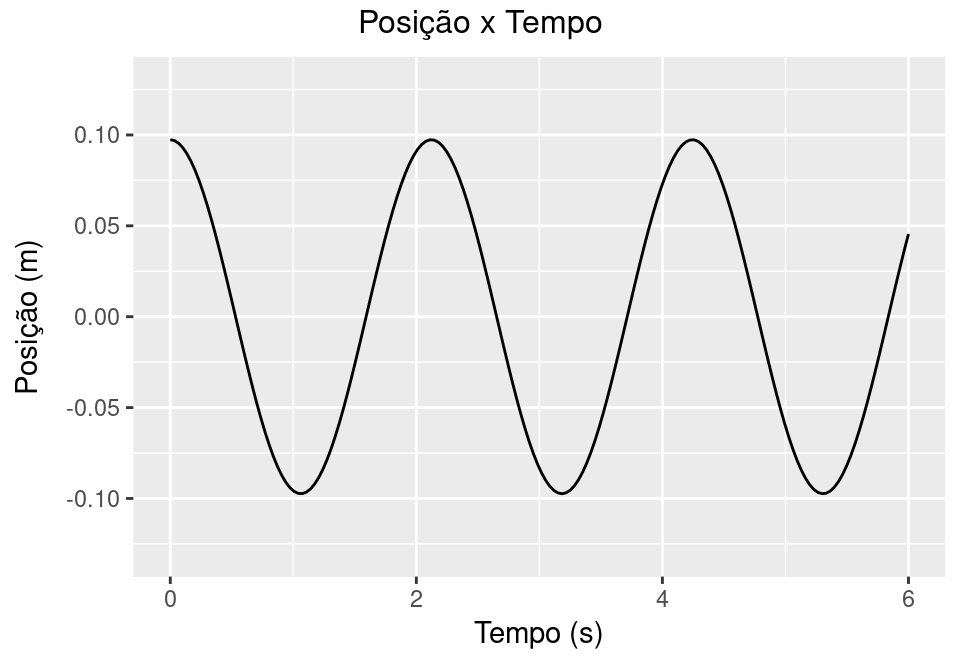

Utilizamos a velocidade no tempo para plotar a função que possui novamente o comportamento de uma senoide, variando entre -0.28 e 0.28 aproximadamente.

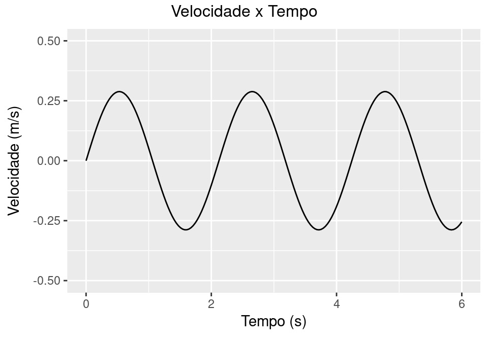

Utilizamos a aceleração do carrinho no tempo para plotar a função que possui comportamento de uma cossenoide, variando entre -0.8 e 0.8.

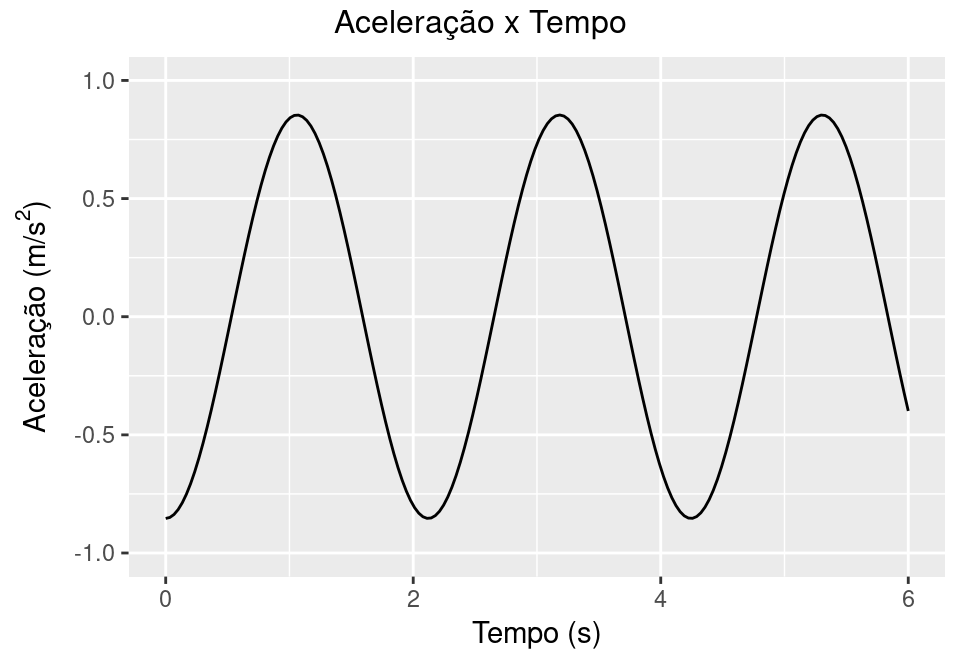

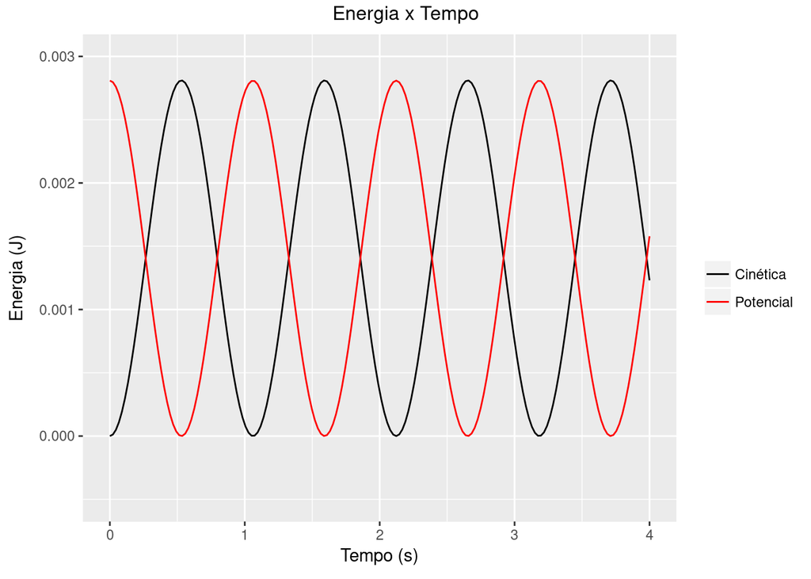